# KSR_2019_Height_Survival_Analysis1

# 1.1 Load packages

```r
library(dplyr)
library(reshape)
library(reshape2)
library(dplyr)
library(tidyr)
```

```r
library(ggplot2)
```

# 1.2 Import data

```r
Data <- read.table("~/R_Projects/CommonGardenExperiment_2019Data/DataAnalysis_FirstHeightSurvivalMeasurement_20190610.csv", na.strings=c("NO PLANT", "none"), blank.lines.skip=TRUE, header=TRUE, sep=",")

Distances <- read.table("~/R_Projects/CommonGardenExperiment_2019Data/Transect_Milkweed_HaversineData_forjoining.csv", na.strings=c("NO PLANT", "none"), blank.lines.skip=TRUE, header=TRUE, sep=",")
```

# 1.2 Remove rows without plants, empty columns

Though 46 holes were dug per 21 rows of the field plot, each hole was not filled with a plant- ex. Row 1 has empty holes until plot column 13. Removing those empty spreadsheet rows as well as empty spreadsheet columns.

```r
b <- is.na(Data$Block) == TRUE
b2 <- c(1:nrow(Data))[b]
Data <- Data[-b2,]
Data <- Data[,-(29:35)]
names(Data)[1]<-"Row"
```

# 1.3 Make certain columns factors

```r
Data$Block <- factor(Data$Block)
Data$Population <- factor(Data$Population)
Data$Family <- factor(Data$Family)
Data$Replicate <- factor(Data$Replicate)

str(Data)
```

```
## 'data.frame':    954 obs. of  28 variables:
##  $ Row             : int  1 1 1 1 1 1 1 1 1 1 ...
##  $ Column          : int  13 14 15 16 17 18 19 20 21 22 ...
##  $ Block           : Factor w/ 4 levels "1","2","3","4": 1 1 1 1 1 1 1 1 1 1 ...
##  $ Population      : Factor w/ 52 levels "1","2","3","4",..: 32 33 13 32 14 38 7 25 14 3 ...
##  $ Family          : Factor w/ 5 levels "1","2","3","4",..: 3 2 2 4 5 4 2 3 5 3 ...
##  $ Replicate       : Factor w/ 5 levels "1","2","3","4",..: 5 5 1 5 5 2 2 5 2 5 ...
##  $ Date_Measured   : Factor w/ 4 levels "6/3/2019","6/4/2019",..: 4 4 4 4 4 4 4 4 4 4 ...
##  $ Note            : Factor w/ 4 levels "","DUG OUT - BIG HOLE IN MIDDLE. PLANT TAKEN?",..: 1 1 1 1 1 1 1 1 1 1 ...
##  $ Num_Ramets      : int  2 1 1 1 0 0 2 0 1 4 ...
##  $ Total_Height    : int  27 10 25 5 0 0 37 0 1 98 ...
##  $ Dead            : Factor w/ 3 levels "maybe","no","nothing there": 2 2 2 2 1 1 2 1 2 2 ...
##  $ Exposed_rhizomes: Factor w/ 3 levels "","no","yes": 3 2 2 2 2 2 3 2 3 3 ...
##  $ Height_Ram1     : int  19 10 25 5 NA NA 20 NA 1 48 ...
##  $ Height_Ram2     : int  8 NA NA NA NA NA 17 NA NA 34 ...
##  $ Height_Ram3     : int  NA NA NA NA NA NA NA NA NA 10 ...
##  $ Height_Ram4     : int  NA NA NA NA NA NA NA NA NA 6 ...
##  $ Height_Ram5     : int  NA NA NA NA NA NA NA NA NA NA ...
##  $ Height_Ram6     : int  NA NA NA NA NA NA NA NA NA NA ...
##  $ Height_Ram7     : int  NA NA NA NA NA NA NA NA NA NA ...
##  $ Height_Ram8     : int  NA NA NA NA NA NA NA NA NA NA ...
##  $ Height_Ram9     : int  NA NA NA NA NA NA NA NA NA NA ...
##  $ Height_Ram10    : int  NA NA NA NA NA NA NA NA NA NA ...
##  $ Height_Ram11    : int  NA NA NA NA NA NA NA NA NA NA ...
##  $ Height_Ram12    : int  NA NA NA NA NA NA NA NA NA NA ...
##  $ Height_Ram13    : int  NA NA NA NA NA NA NA NA NA NA ...
##  $ Height_Ram14    : int  NA NA NA NA NA NA NA NA NA NA ...
##  $ Height_Ram15    : int  NA NA NA NA NA NA NA NA NA NA ...
##  $ Measurer        : Factor w/ 2 levels "Sophie","Vanessa": 2 2 2 2 2 2 2 2 2 2 ...
```

# 1.4 Create survival table

Table (then, data frame) shows each population x family combination (up to 5 families per population), alongside how many plants per population’s family might be alive (column “maybe”), is definitely alive (column “no”), and is not alive because there was no plant found in the pot (column “nothing there”). These 3 categories are answers to the question, “is the plant dead?”.

```r
tab1 <- table(Data$Population,Data$Family, Data$Dead)
tab2 <- as.data.frame(tab1)
names(tab2)[1]<-"Population"
names(tab2)[2]<-"Family"
names(tab2)[3]<-"Dead"

a <- spread(tab2, Dead, Freq)
```

# 1.5 Edit table

Adding a “Total” column showing the total number of plants per population family. If the “Total” column = 0, removing that row. Before planting, that family had not been represented with replicates in the first place.

```r
a$Total <- NA
names(a)[5] <- "nothing_there"
a$Total <- rowSums(a[3:5])

a$maybe <- as.numeric(a$maybe)
a$no <- as.numeric(a$no)
a$nothing_there <- as.numeric(a$nothing_there)

a<-a[!(a$Total==0),] # removing rows corresponding to populations' a priori empty families
```

# 1.6 Find probable, definite survival percentages per family

Adding two columns which indicate the percentage of plants per family that are definitely alive (all dead=no plants) or probably alive (all dead=no plants + half of dead=maybe plants).

```r
a$Pct_Survival_Definite <- NA
a$Pct_Survival_Definite <- a$no/a$Total # definite survival assumes none of "maybe" milkweed survive
a$Pct_Survival_Definite <- signif(a$Pct_Survival_Definite, 2)*100

a$Pct_Survival_Probably <- NA
a$Pct_Survival_Probably <- (a$no + 0.5*a$maybe)/a$Total  # probable survival assumes half of "maybe" milkweed survive
a$Pct_Survival_Probably <- signif(a$Pct_Survival_Probably, 2)*100

a
```

|  | Population | Family | maybe | no | nothing_there | Total | Pct_Survival_Definite | Pct_Survival_Probably |
| --- | --- | --- | --- | --- | --- | --- | --- | --- |
| 1 | 1 | 1 | 0 | 5 | 0 | 5 | 100 | 100 |
| 2 | 1 | 2 | 1 | 4 | 0 | 5 | 80 | 90 |
| 3 | 1 | 3 | 2 | 3 | 0 | 5 | 60 | 80 |
| 4 | 1 | 4 | 2 | 3 | 0 | 5 | 60 | 80 |
| 5 | 1 | 5 | 0 | 4 | 1 | 5 | 80 | 80 |
| 6 | 2 | 1 | 1 | 3 | 1 | 5 | 60 | 70 |
| 7 | 2 | 2 | 0 | 5 | 0 | 5 | 100 | 100 |
| 8 | 2 | 3 | 0 | 5 | 0 | 5 | 100 | 100 |
| 9 | 2 | 4 | 1 | 3 | 1 | 5 | 60 | 70 |
| 10 | 2 | 5 | 3 | 1 | 1 | 5 | 20 | 50 |

[output cut: 198 more lines]

# 1.7 Find probable, definite survival percentages per population

```r
e <- a %>% group_by(Population) %>% summarise(sum_no = sum(no),
                                              sum_maybe = sum(maybe),
                                              sum_nothingthere = sum(nothing_there),
                                              sum_total = sum(Total))

e$Pct_Survival_Definite <- NA
e$Pct_Survival_Definite <- e$sum_no/e$sum_total # definite survival assumes none of "maybe" milkweed survive
e$Pct_Survival_Definite <- signif(e$Pct_Survival_Definite, 2)*100

e$Pct_Survival_Probably <- NA
e$Pct_Survival_Probably <- (e$sum_no + 0.5*e$sum_maybe)/e$sum_total # probable survival assumes half of "maybe" milkweed survive
e$Pct_Survival_Probably <- signif(e$Pct_Survival_Probably, 2)*100

e
```

| Population | sum_no | sum_maybe | sum_nothingthere | sum_total | Pct_Survival_Definite | Pct_Survival_Probably |
| --- | --- | --- | --- | --- | --- | --- |
| 1 | 19 | 5 | 1 | 25 | 76 | 86 |
| 2 | 17 | 5 | 3 | 25 | 68 | 78 |
| 3 | 15 | 6 | 1 | 22 | 68 | 82 |
| 4 | 16 | 7 | 2 | 25 | 64 | 78 |
| 5 | 15 | 4 | 6 | 25 | 60 | 68 |
| 6 | 15 | 8 | 1 | 24 | 62 | 79 |
| 7 | 21 | 2 | 2 | 25 | 84 | 88 |
| 8 | 11 | 1 | 3 | 15 | 73 | 77 |
| 9 | 10 | 0 | 0 | 10 | 100 | 100 |
| 11 | 12 | 1 | 3 | 16 | 75 | 78 |

[output cut: 42 more lines]

```r
f <- as.data.frame(table(Data$Dead)) # total plants for each mortality status
names(f)[1]<-"Dead?"
names(f)[2]<-"Count"
f[1,2] + f[2,2] + f[3,2] # Total plants
```

```
## [1] 953
```

```r
f
```

| Dead? | Count |
| --- | --- |
| maybe | 209 |
| no | 641 |
| nothing there | 103 |

# 1.8 Plot of survival per population vs. distance from city center

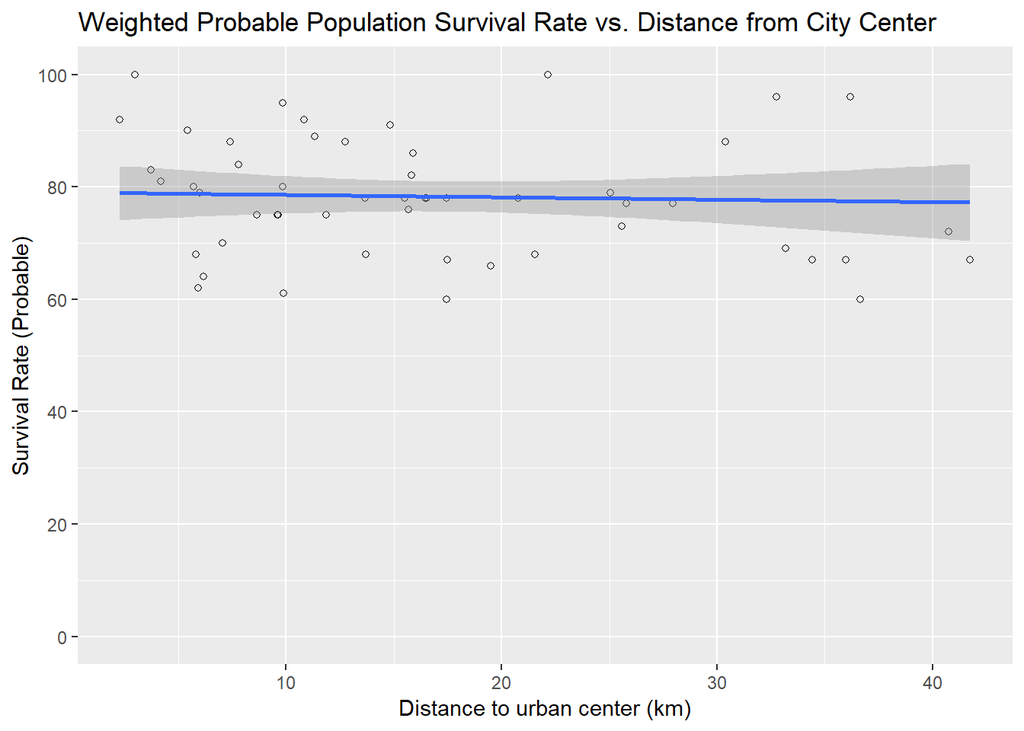

```r
# When population location is spread over a few sites (e.g. there are several AS identifiers and only 1 MW identifier), coordinates chosen correspond to first AS site. E.g. For MW003, there are two AS sites- AS003 & AS004. AS003 will be designated to show the location of MW003. Same practice for MW004, 005, 006, 007.

Dist_merged <- merge(x = e, y = Distances, by = "Population", all.x = TRUE)

# Plot and stats for probable percent survival vs. distance from city center (weighted by total plants per population)
fig1 <- ggplot(Dist_merged, aes(x = Dist_city_center_km_Yonge_Bloor, y = Pct_Survival_Probably, weights=Dist_merged$sum_total)) +
  labs(x = "Distance to urban center (km)", y = "Survival Rate (Probable)") +
  geom_point(shape=21) +
  geom_smooth(method = "lm", se = T, mapping = aes(weight = Dist_merged$sum_total*0.5)) +
  scale_y_continuous(breaks=c(0,20, 40, 60,80,100), limits=c(0,100)) +
  ggtitle('Weighted Probable Population Survival Rate vs. Distance from City Center')
fig1
```

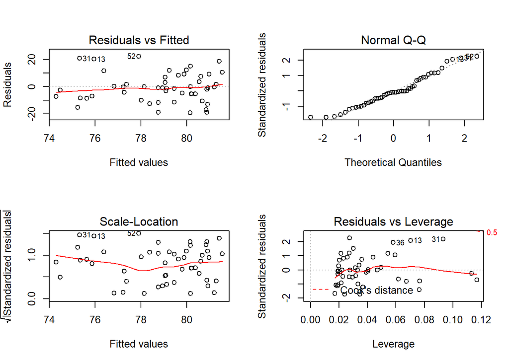

```r
Fig1_stats <- lm(Pct_Survival_Probably ~ Dist_city_center_km_Yonge_Bloor, data=Dist_merged, weights=sqrt(Dist_merged$Pct_Survival_Probably))
par(mfrow=c(2,2))
plot(Fig1_stats)
```

```r
summary(Fig1_stats)
```

```
##
## Call:
## lm(formula = Pct_Survival_Probably ~ Dist_city_center_km_Yonge_Bloor,
##     data = Dist_merged, weights = sqrt(Dist_merged$Pct_Survival_Probably))
##
## Weighted Residuals:
##     Min      1Q  Median      3Q     Max
## -53.525 -21.606  -2.781  21.537  69.910
##
## Coefficients:
##                                 Estimate Std. Error t value Pr(>|t|)
## (Intercept)                      81.9737     2.7317  30.008   <2e-16 ***
## Dist_city_center_km_Yonge_Bloor  -0.1842     0.1380  -1.334    0.188
## ---
## Signif. codes:  0 '***' 0.001 '**' 0.01 '*' 0.05 '.' 0.1 ' ' 1
##
## Residual standard error: 31.44 on 50 degrees of freedom
## Multiple R-squared:  0.03439,    Adjusted R-squared:  0.01508
## F-statistic: 1.781 on 1 and 50 DF,  p-value: 0.1881
```

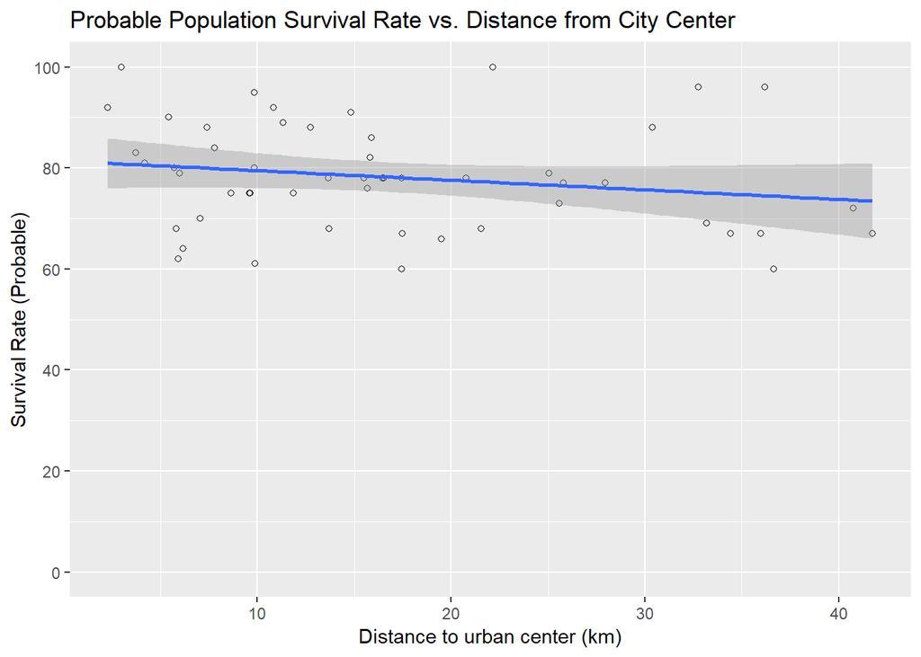

```r
# Plot and stats for probable percent survival vs. distance from city center
fig2 <- ggplot(Dist_merged, aes(x = Dist_city_center_km_Yonge_Bloor, y = Pct_Survival_Probably)) +
  labs(x = "Distance to urban center (km)", y = "Survival Rate (Probable)") +
  geom_point(shape=21) +
  geom_smooth(method = "lm", se = T) +
  scale_y_continuous(breaks=c(0,20, 40, 60,80,100), limits=c(0,100)) +
  ggtitle('Probable Population Survival Rate vs. Distance from City Center')
fig2
```

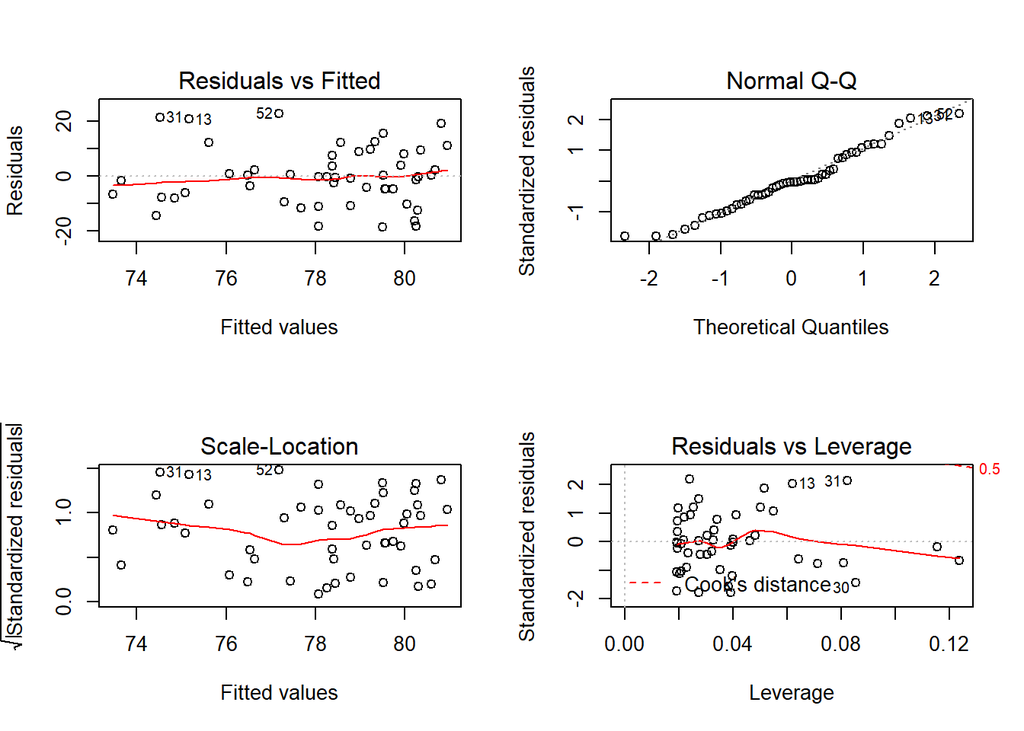

```r
Fig2_stats <- lm(Pct_Survival_Probably ~ Dist_city_center_km_Yonge_Bloor, data=Dist_merged)
par(mfrow=c(2,2))
plot(Fig2_stats)
```

```r
summary(Fig2_stats)
```

```
##
## Call:
## lm(formula = Pct_Survival_Probably ~ Dist_city_center_km_Yonge_Bloor,
##     data = Dist_merged)
##
## Residuals:
##      Min       1Q   Median       3Q      Max
## -18.5123  -6.7321  -0.2852   7.7247  22.8199
##
## Coefficients:
##                                 Estimate Std. Error t value Pr(>|t|)
## (Intercept)                      81.3922     2.7228  29.893   <2e-16 ***
## Dist_city_center_km_Yonge_Bloor  -0.1901     0.1365  -1.392     0.17
## ---
## Signif. codes:  0 '***' 0.001 '**' 0.01 '*' 0.05 '.' 0.1 ' ' 1
##
## Residual standard error: 10.53 on 50 degrees of freedom
## Multiple R-squared:  0.03731,    Adjusted R-squared:  0.01806
## F-statistic: 1.938 on 1 and 50 DF,  p-value: 0.17
```

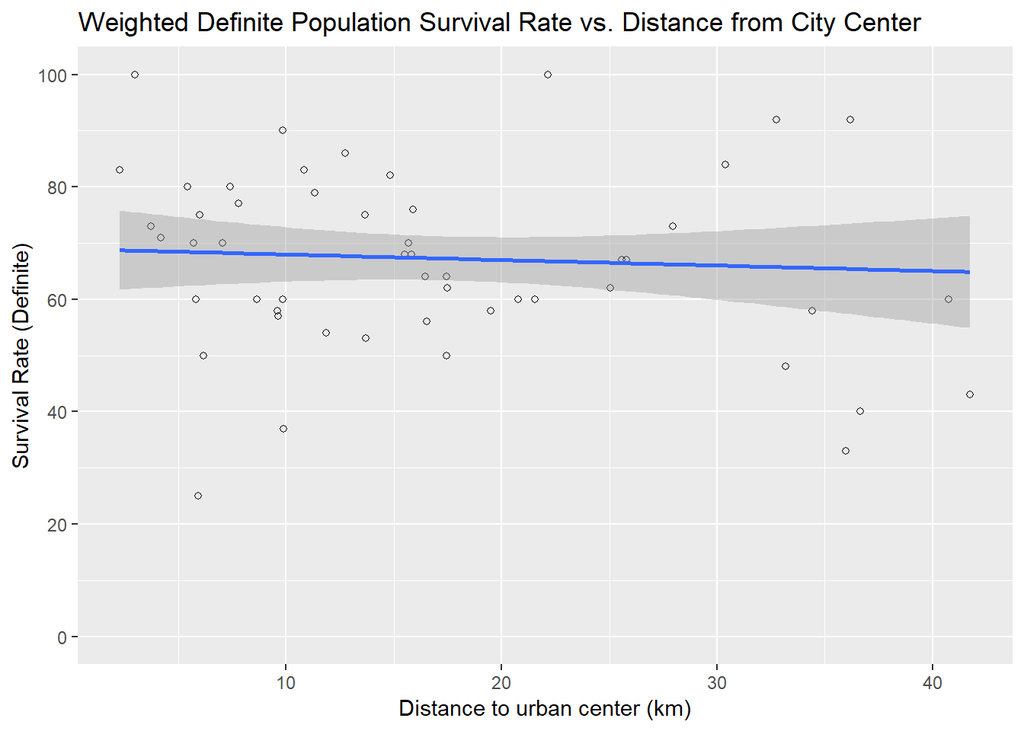

```r
# Plot and stats for definite percent survival vs. distance from city center (weighted by total plants per population)
fig3 <- ggplot(Dist_merged, aes(x = Dist_city_center_km_Yonge_Bloor, y = Pct_Survival_Definite, weights=Dist_merged$sum_total)) +
  labs(x = "Distance to urban center (km)", y = "Survival Rate (Definite)") +
  geom_point(shape=21) +
  geom_smooth(method = "lm", se = T, mapping = aes(weight = Dist_merged$sum_total*0.5)) +
  scale_y_continuous(breaks=c(0,20, 40, 60,80,100), limits=c(0,100)) +
  ggtitle('Weighted Definite Population Survival Rate vs. Distance from City Center')
fig3
```

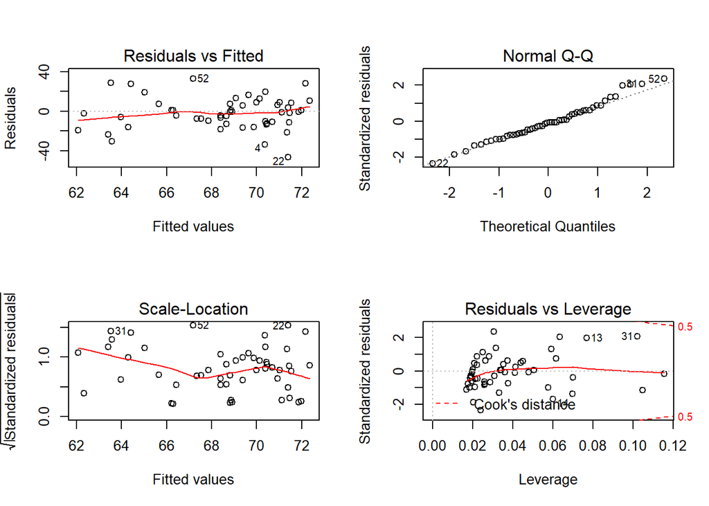

```r
Fig3_stats <- lm(Pct_Survival_Definite ~ Dist_city_center_km_Yonge_Bloor, data=Dist_merged, weights=sqrt(Dist_merged$Pct_Survival_Definite))
par(mfrow=c(2,2))
plot(Fig3_stats)
```

```r
summary(Fig3_stats)
```

```
##
## Call:
## lm(formula = Pct_Survival_Definite ~ Dist_city_center_km_Yonge_Bloor,
##     data = Dist_merged, weights = sqrt(Dist_merged$Pct_Survival_Definite))
##
## Weighted Residuals:
##     Min      1Q  Median      3Q     Max
## -103.78  -32.48   -3.75   22.40  103.80
##
## Coefficients:
##                                 Estimate Std. Error t value Pr(>|t|)
## (Intercept)                      72.9610     4.0666   17.94   <2e-16 ***
## Dist_city_center_km_Yonge_Bloor  -0.2611     0.2072   -1.26    0.213
## ---
## Signif. codes:  0 '***' 0.001 '**' 0.01 '*' 0.05 '.' 0.1 ' ' 1
##
## Residual standard error: 44.74 on 50 degrees of freedom
## Multiple R-squared:  0.03079,    Adjusted R-squared:  0.01141
## F-statistic: 1.588 on 1 and 50 DF,  p-value: 0.2134
```

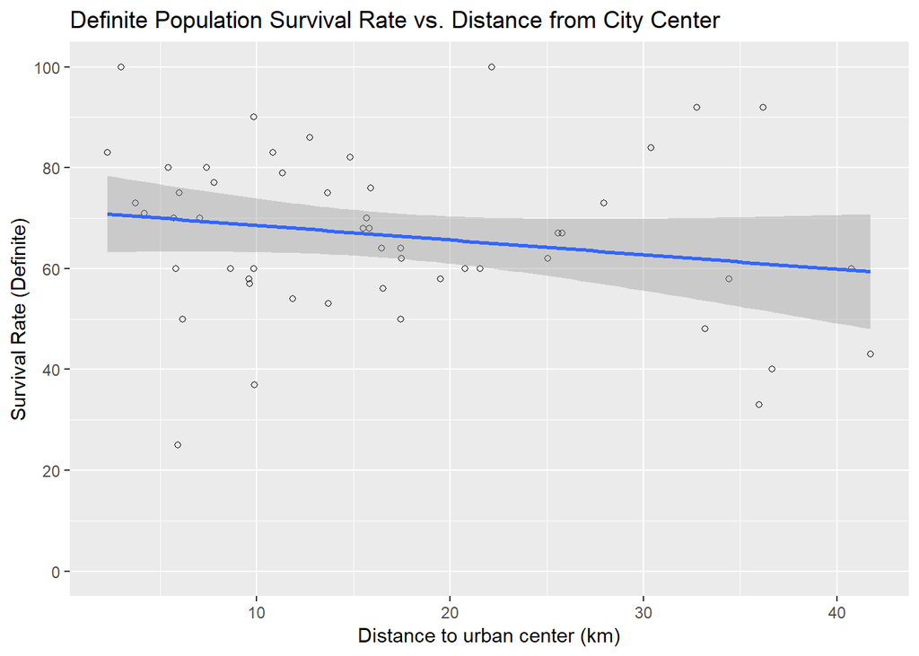

```r
# Plot and stats for definite percent survival vs. distance from city center
fig4 <- ggplot(Dist_merged, aes(x = Dist_city_center_km_Yonge_Bloor, y = Pct_Survival_Definite)) +
  labs(x = "Distance to urban center (km)", y = "Survival Rate (Definite)") +
  geom_point(shape=21) +
  geom_smooth(method = "lm", se = T) +
  scale_y_continuous(breaks=c(0,20, 40, 60,80,100), limits=c(0,100)) +
  ggtitle('Definite Population Survival Rate vs. Distance from City Center')
fig4
```

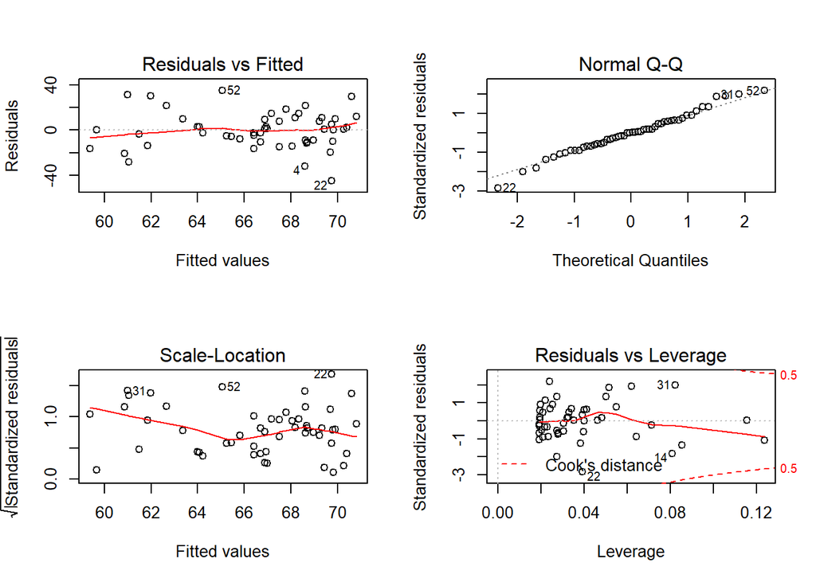

```r
Fig4_stats <- lm(Pct_Survival_Definite ~ Dist_city_center_km_Yonge_Bloor, data=Dist_merged)
par(mfrow=c(2,2))
plot(Fig4_stats)
```

```r
summary(Fig4_stats)
```

```
##
## Call:
## lm(formula = Pct_Survival_Definite ~ Dist_city_center_km_Yonge_Bloor,
##     data = Dist_merged)
##
## Residuals:
##     Min      1Q  Median      3Q     Max
## -44.761 -10.016   0.453   9.743  34.949
##
## Coefficients:
##                                 Estimate Std. Error t value Pr(>|t|)
## (Intercept)                      71.4817     4.1709  17.138   <2e-16 ***
## Dist_city_center_km_Yonge_Bloor  -0.2902     0.2091  -1.388    0.171
## ---
## Signif. codes:  0 '***' 0.001 '**' 0.01 '*' 0.05 '.' 0.1 ' ' 1
##
## Residual standard error: 16.12 on 50 degrees of freedom
## Multiple R-squared:  0.03708,    Adjusted R-squared:  0.01782
## F-statistic: 1.925 on 1 and 50 DF,  p-value: 0.1714
```